# Actividad 1.6

Lucero Díaz

2026-10-03

## Problema 1

Considere la matriz de datos siguiente $X=\begin{bmatrix} 1 & 4 & 3 \\ 6 & 2 & 6 \\ 8 & 3 & 3 \end{bmatrix}$ que consta de 3 observaciones (filas) y 3 variables (columnas)

$$b'X=\begin{bmatrix} 1 & 1 &
1 \end{bmatrix} \begin{bmatrix} X_1 \\ X_2 \\ X_3 \end{bmatrix} = X_1 +
X_2 + X_3$$
$$c'X=\begin{bmatrix}
1 & 2 & -3 \end{bmatrix} \begin{bmatrix} X_1 \\ X_2 \\ X_3
\end{bmatrix} = X_1 + 2X_2 - 3X_3$$

```r
# Definición de matrices
X <- matrix(c(1, 4, 3,
              6, 2, 6,
              8, 3, 3), ncol=3, byrow = TRUE)

b <- matrix(c(1, 1, 1), ncol=3, byrow = TRUE)

c <- matrix(c(1, 2, -3), ncol=3, byrow = TRUE)
```

```r
# a) Hallar la media, varianza y covarianza de X
mu_X = colMeans(X)
s_X = cov(X)
sigma_X = diag(s_X)
cat("Vector de medias: "); print(mu_X)
```

```
## Vector de medias:
```

```
## [1] 5 3 4
```

```r
cat("\nVarianzas individuales: "); print(sigma_X)
```

```
##
## Varianzas individuales:
```

```
## [1] 13  1  3
```

```r
cat("\nMatriz de varianzas-covarianzas: \n"); print(s_X)
```

```
##
## Matriz de varianzas-covarianzas:
```

```
##      [,1] [,2] [,3]
## [1,] 13.0 -2.5  1.5
## [2,] -2.5  1.0 -1.5
## [3,]  1.5 -1.5  3.0
```

```r
# b) Hallar la media, varianza y covarianza de b'X y c'X
mu_bX = b %*% mu_X
mu_cX = c %*% mu_X
s_bX = b %*% s_X %*% t(b)
s_cX = c %*% s_X %*% t(c)
s_bX_cX = b %*% s_X %*% t(c)
cat("\nVector de medias de b'X: \n"); print(mu_bX)
```

```
##
## Vector de medias de b'X:
```

```
##      [,1]
## [1,]   12
```

```r
cat("\nVector de medias de c'X: \n"); print(mu_cX)
```

```
##
## Vector de medias de c'X:
```

```
##      [,1]
## [1,]   -1
```

```r
cat("\nVarianza de b'X: \n"); print(s_bX)
```

```
##
## Varianza de b'X:
```

```
##      [,1]
## [1,]   12
```

```r
cat("\nVarianza de c'X: \n"); print(s_cX)
```

```
##
## Varianza de c'X:
```

```
##      [,1]
## [1,]   43
```

```r
cat("\nCovarianza de b'X y c'X: \n"); print(s_bX_cX)
```

```
##
## Covarianza de b'X y c'X:
```

```
##      [,1]
## [1,]   -3
```

```r
# c) Hallar el determinante de S (matriz de var-covarianzas de X)
d = det(s_X)
cat("\nDeterminante de la matriz de varianzas-covarianzas de X: \n"); print(d)
```

```
##
## Determinante de la matriz de varianzas-covarianzas de X:
```

```
## [1] 0
```

```r
# d) Hallar los valores y vectores propios de S
v_propios = eigen(s_X)
cat("\nValores propios: \n"); print(v_propios$values)
```

```
##
## Valores propios:
```

```
## [1]  1.379150e+01  3.208497e+00 -7.859007e-17
```

```r
cat("\nVectores propios: \n"); print(v_propios$vectors)
```

```
##
## Vectores propios:
```

```
##            [,1]       [,2]       [,3]
## [1,]  0.9645458 -0.2295697 -0.1301889
## [2,] -0.2076189 -0.3555080 -0.9113224
## [3,]  0.1629288  0.9060418 -0.3905667
```

### e) Argumentar si hay independencia entre b’X y c’X , ¿y qué ocurre con X1, X2 y X3? ¿son independientes?

Como la covarianza entre b’X y c’X no es 0, con esto descartamos independencia entre ambas matrices. Y con respecto a las variables X1, X2 y X3, tampoco son independientes entre sí, puesto que también las covarianzas entre cada par de variables son distintas de 0; además, el determinante de la matriz de varianzas-covarianzas de X, conocido también como varianza generalizada, es igual a 0, lo que nos confirma que existe una dependencia lineal entre las variables de X (es decir, hay al menos una variable que es la combinación lineal de las demás).

### f) Hallar la varianza generalizada de S. Explicar el comportamiento de los datos de X basándose en la varianza generalizada, en los valores y vectores propios de S.

Como mencionamos anteriormente, sabemos que la varianza generalizada de S es su determinante, es decir, es igual a 0. Esto implica que los datos de X no llenan un espacio de 3 dimensiones, sino que se quedan en un espacio bidimensional. Por lo tanto, sabemos que al menos uno de los valores propios de S es igual a 0 (en el código no se muestra explícitamente por limitaciones computacionales, pero muestra un valor propio como un número extremadamente pequeño). Con esto sabemos que los primeros dos componentes principales son los que explican toda la variabilidad, es decir, la suma de los dos valores propios restantes es igual a la suma total de las varianzas individuales. Tenniendo esto en cuenta, con los valores propios no nulos y sus respectivos vectores propios podemos explicar el contorno de densidad, y al menos sabemos que la elipsoide será plana en uno de los 3 ejes, lo que implica una elipsoide bidimensional.

## Problema 2

Explore los resultados del siguiente código y dé una interpretación (se sugiere intersertarlo en un trozo de R en Rmarkdown para que dé varias ventanas de salida de resutados):

```r
library(MVN)
```

```r
x = rnorm(100, 10, 2)
y = rnorm(100, 10, 2)
datos = data.frame(x,y)
# Prueba de Henze-Zirkler con mvn()
resultado <- mvn(datos, mvn_test = "hz")
plot(resultado, type = "persp")
```

[interactive chart not shown]

```r
plot(resultado, type = "contour")
```

[interactive chart not shown]

El código crea dos variables x y y, las cuales se distribuyen de manera normal con media 10 y desviación estándar de 2, generando así 100 observaciones de manera aleatoria para cada variable. Se realiza la prueba de normalidad bivariada Henze-Zirkler, así como también se grafican la función de densidad tridimensional (que tiene una forma de campana), y los contornos de densidad de esta campana, donde se observa la región y el porcentaje de datos que acumula cada contorno y a qué altura.

```r
#En otro chunck escribe los resultados:
resultado
```

```
## $multivariate_normality
##            Test Statistic p.value     Method      MVN
## 1 Henze-Zirkler      0.71   0.223 asymptotic ✓ Normal
##
## $univariate_normality
##               Test Variable Statistic p.value Normality
## 1 Anderson-Darling        x     0.292   0.600  ✓ Normal
## 2 Anderson-Darling        y     0.434   0.296  ✓ Normal
##
## $descriptives
##   Variable   n   Mean Std.Dev Median   Min    Max  25th   75th   Skew Kurtosis
## 1        x 100  9.579   2.000  9.681 3.619 14.318 8.194 10.979 -0.065    2.756
## 2        y 100 10.558   1.906 10.673 4.861 14.521 9.302 11.961 -0.463    3.061
##
## $data
```

[output cut: 110 more lines]

En los resultados observamos como los p-values tanto de cada distribución univariada como de la distribución bivariada son mayores a 0.05, lo que no rechaza la hipótesis nula de normalidad. Además, se observa como tanto el sesgo como la curtosis de tanto x como de y no se alejan mucho de los valores esperados para simetría y una distribución mesocúrtica (resultados cercanos a 0 para el sesgo y cercanos a 3 para la curtosis).

## Problema 3

Un periódico matutino enumera los siguientes precios de autos usados para un compacto extranjero con edad medida en años y precio en venta medido en miles de dólares.

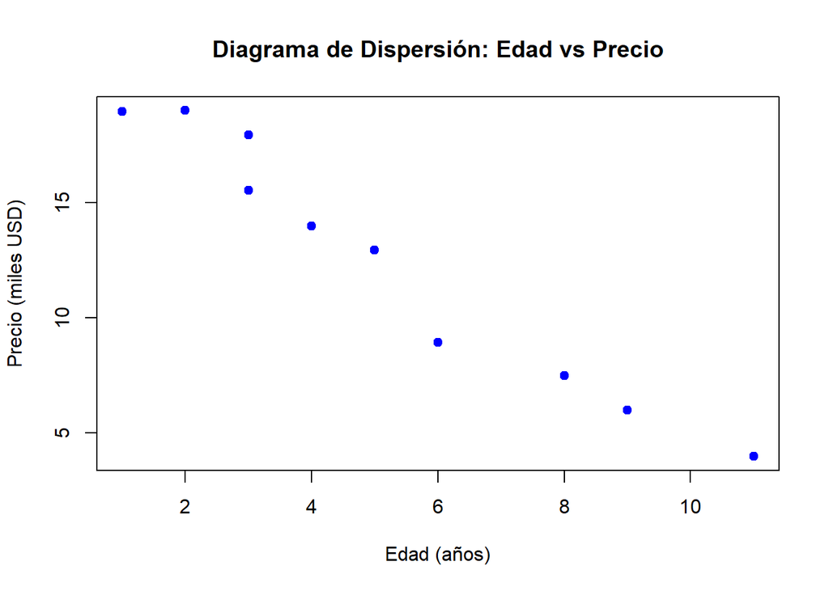

```r
x1 <- c(1, 2, 3, 3, 4, 5, 6, 8, 9, 11)
x2 <- c(18.95, 19.00, 17.95, 15.54, 14.00, 12.95, 8.94, 7.49, 6.00, 3.99)
datos_cars <- cbind(x1, x2)

# a) Diagrama de dispersión
plot(x1, x2,
     main = "Diagrama de Dispersión: Edad vs Precio",
     xlab = "Edad (años)",
     ylab = "Precio (miles USD)",
     pch = 19, col = "blue")
```

### b) Inferir el signo de la covarianza muestral a partir del gráfico.

Por el comportamiento de la relación entre ambas variables, se puede inferir que el signo de la covarianza muestral es negativo, al mostrar como tendencia una función lineal con pendiente negativa.

```r
# c) Distancias de Mahalanobis al cuadrado d_j^2
x_bar_cars <- colMeans(datos_cars)
S_cars <- cov(datos_cars)
d2 <- mahalanobis(datos_cars, center = x_bar_cars, cov = S_cars)

cat("\nCuadrado de las Distancias de Mahalanobis \n")
```

```
##
## Cuadrado de las Distancias de Mahalanobis
```

```r
print(round(d2, 4))
```

```
##  [1] 1.8753 2.0203 2.9009 0.7353 0.3105 0.0176 3.7329 0.8165 1.3753 4.2153
```

```r
# d) Proporción dentro del contorno del 50% de probabilidad
val_critico_50 <- qchisq(0.50, df = 2)
dentro_50 <- d2 <= val_critico_50
prop_50 <- mean(dentro_50)

cat("\nProporción en el Contorno del 50% \n")
```

```
##
## Proporción en el Contorno del 50%
```

```r
cat("Valor crítico Chi-cuadrado (50%):", round(val_critico_50, 4), "\n")
```

```
## Valor crítico Chi-cuadrado (50%): 1.3863
```

```r
cat("Observaciones dentro del contorno:", sum(dentro_50), "de 10\n")
```

```
## Observaciones dentro del contorno: 5 de 10
```

```r
cat("Proporción observada:", prop_50, "\n")
```

```
## Proporción observada: 0.5
```

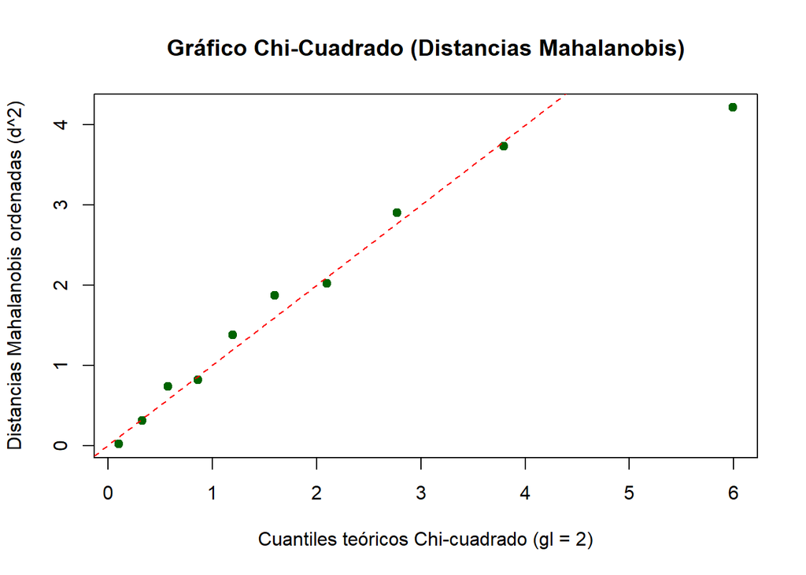

```r
# e) Gráfico Chi-cuadrado (Q-Q plot multivariado)
d2_ordenadas <- sort(d2)
n <- length(x1)
j <- 1:n
cuantiles_chi2 <- qchisq((j - 0.5) / n, df = 2)

plot(cuantiles_chi2, d2_ordenadas,
     main = "Gráfico Chi-Cuadrado (Distancias Mahalanobis)",
     xlab = "Cuantiles teóricos Chi-cuadrado (gl = 2)",
     ylab = "Distancias Mahalanobis ordenadas (d^2)",
     pch = 19, col = "darkgreen")
abline(0, 1, lty = 2, col = "red")
```

### f) Dados los resultados anteriores, serían argumentos para decir que son aproximadamente normales bivariados?

Viendo los resultados, sí podría considerarse que estos están distribuidos como una normal bivariada. Esto ya que la proporción muestral del contorno de probabilidad de 50% es exactamente 0.5, lo que apoya el valor teórico. Además, al momento de realizar el gráfico de Chi-Cuadrado se observa una fuerte relación entre los datos y la función lineal planteada, así como tampoco se muestran una cantidad considerable de datos atípicos.

## Declaratoria de uso de IA durante el desarrollo del trabajo

Se utilizó IA:

1. Herramienta: Gemini
2. Uso realizado: Ayuda en el código a lo largo de la tarea, específicamente en el último problema del documento, al momento de hacer la gráfica de dispersión, el gráfico de Chi-cuadrado, las distancias de Mahanalobis, y la proporción del contorno de 50%.
3. Secciones donde se utilizó: Problemas 3, en los incisos a), c), d) y e).
4. Validación realizada por los estudiantes: Se verificó, corrió y depuró todo el script de R, así como también analizaron todos los resultados arrojados para validar que todo estuviera correcto y en orden.
5. Confirmo de que se revisó, verificó y que se asume la responsabilidad del contenido final entregado.